```python
#%%

#

import string
from urllib import response
import pandas as pd
import re
import requests
```

# Load the scrapped raw twitter dataset (tweets containing misinformation) as pandas dataframe

```python
df = pd.read_csv('scraped_tweets.csv')
```

Print columns of the dataset

```python
print(df.columns)
```

```
Index(['Unnamed: 0', 'username', 'description', 'location', 'following',
       'followers', 'totaltweets', 'retweetcount', 'text', 'hashtags'],
      dtype='object')
```

# Extract url text using str extract

```python
df['url'] = df['text'].str.extract('(....-..-..)', expand=True)
```

```python
ulist = []
```

# Exract the url correclty using regular expression.

Text may contain other words other than url, so here i used regular expression to extract the url along. Url will be of the form http followed by /: and letters and numbers, then saving into a list called ulist.

```python
for i in df['text']:
    #print (i)

    #print(re.findall('http[a-zA-Z/:.0-9]+', i))

    ulist.append(re.findall('http[a-zA-Z/:.0-9]+', i))
```

```python
print(ulist)
```

```
[['https://t.co/DZ3NBWYP7q'], ['https://t.co/Si54yfECkf'], ['https://t.co/qeIxlIB98W', 'https://t.co/dYrcAd0l2Q'], ['https://t.co/XAcyiGFjRq'], ['https://t.co/udYdxR00hB'], ['https://t.co/5P8kSjtf3g'], ['https://t.co/kBJzXdEDG7', 'https://t.co/nUNCYsKjeR'], ['https://t.co/1MxJvkUCrd'], ['https://t.c…
```

# Adding the url list to the data frame of the original dataset.

After adding the url list to the dataset as a column, so for each each , the respective url is added to it's row.

But still these urls are in their tiny url form

```python
df['url'] = ulist

print(df)
```

```
    Unnamed: 0         username  \
0            0       C_Coolidge
1            1   5smooth_stones
2            2  healthmatrixnet
3            3        21Earther
4            4  socioecohistory
5            5   ellaadams20161
6            6     GingerMcFall
7            7    behemoth_mark
8            8    johnwood20191
9            9  sherivandenburg
10          10  HowWeLostTheWar
11          11       chika_sara
12          12           126mgp
13          13  DidrikStrandell
```

[output cut: 355 more lines]

```python
df.columns
```

```
Index(['Unnamed: 0', 'username', 'description', 'location', 'following',
       'followers', 'totaltweets', 'retweetcount', 'text', 'hashtags', 'url'],
      dtype='object')
```

```python
df['url']
```

```
0                             [https://t.co/DZ3NBWYP7q]
1                             [https://t.co/Si54yfECkf]
2     [https://t.co/qeIxlIB98W, https://t.co/dYrcAd0...
3                             [https://t.co/XAcyiGFjRq]
4                             [https://t.co/udYdxR00hB]
5                             [https://t.co/5P8kSjtf3g]
6     [https://t.co/kBJzXdEDG7, https://t.co/nUNCYsK...
7                             [https://t.co/1MxJvkUCrd]
8                             [https://t.co/1MxJvkUCrd]
9                             [https://t.co/1MxJvkUCrd]
10                            [https://t.co/DZ3NBWYP7q]
11    [https://t.co/STyl0WXhhs, https://t.co/WuE22tt...
12                            [https://t.co/DZ3NBWYP7q]
13                            [https://t.co/DZ3NBWYP7q]
14    [https://t.co/VZC7ZHEdKs, https://t.co/ldwUgkX...
```

[output cut: 37 more lines]

# finding and adding the real domain name to the df from short url.

# Here, i used regular expression with python get request to get the original url form the short url.I have used BeautifulSoup web scrapping python library for getting the website title name.

# This is saved into a list, and is added to the dataframe

```python
d = []

t = []

#url = (df['url'][1])

for i in df['url']:

    lofl = []

    for f in range(len(i)):


        try:

            s = str((i[f]))
            s = re.sub(r"[^a-zA-Z/:.0-9]","",s)

            response = requests.get(s)

            url = response.url



            from urllib.parse import urlparse

            domain = urlparse(url).netloc

            d.append(domain)

            lofl.append(domain)

            from urllib.request import urlopen
            from bs4 import BeautifulSoup


            soup = BeautifulSoup(urlopen(s))


            #print("Title of the website is : ")
            t.append(soup.title.get_text())

        except:

            print('http error occured')
            #d.append('http error occured')
            #lofl.append('http error occured')


        #d.append(lofl)
        #print(url)
```

[output not shown]

```python
print(d)
```

```
['web.archive.org', 'nworeport.me', 'www.sott.net', 'www.sott.net', 'nworeport.me', 'www.audioplace.me', 'www.stcu.int', 'twitter.com', 'gilbertdoctorow.com', 'gilbertdoctorow.com', 'gilbertdoctorow.com', 'web.archive.org', 'www.stcu.int', 'twitter.com', 'web.archive.org', 'web.archive.org', 'world2…
```

# Getting thr domain column seperatly for further analysis

```python
print(t)


domaindf = pd.DataFrame (d, columns = ['domain'])
```

```
['Минобороны рассказало о связи сына Байдена с лабораториями США на Украине - РИА Новости, 24.03.2022', 'Russia makes new allegations about US-funded biolabs in Ukraine – Nwo Report', 'Russia makes new allegations about US-funded biolabs in Ukraine – Nwo Report', 'Give your story a voice | Audioplac…
```

```python
domaincat = pd.Categorical(domaindf)
```

# Visualizing the domians

During the war it has been reported that russian has been creating these sites to spread misinformation , thus by spreading it massively in social media

Second most used site are pointing back to the twitter itself.Showing that people are sharing moslty what others has shared on the twitter , without verifying the authencity from the externam source, can be one of the main reason of spreading misinformation very fastly on social media.

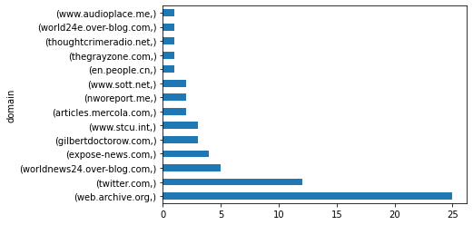

```python
domaindf.value_counts().plot(kind='barh')
```

```python
#import geopandas

#import geoplot
```

```python
# import pygal
# from pygal_maps_world.maps import World


# worldmap_chart = World()


# worldmap_chart.title = 'Some countries'
# #%%
# worldmap_chart.add('F countries', ['fr', 'fi'])

# #%%
# worldmap_chart.render_to_file('chart.svg')
```

```python
import pandas as pd
import tweepy
#User created date
```

# Identifying sockpuppets/fake ids used for spreading misinformation

One of the easiest way to identify sock puppets or fake ids are using their IP adress, which twitter did not provide.

So other easiest way is to find the time of craetion of the accounts used.

If majority of the accounts which shared misinformation was created on the same time, or was created few days back the post beign shared, we can suspect planned activity in spreading misinformation on social media.

Here using tweepy , i have find the account creation time of every twitter id's which shared the misinformation on the russia - ukrain war in our dataset on twitter.

```python
creation_date = []

consumer_key = "xSh8QKijNpCVCAz8SfC0vAax3"
consumer_secret = "eAnkQQhCbm7LbGZzJZ4bjykNdpQ31ygvzpML9fquDE490avfhA"
access_key = "1505336309065424908-CJx9O2IEukeycT3Nm2cet1eY89R6tj"
access_secret = "wnoq7Eh81nDVfeadY0zzfAGrJ0dTOn1rcD2vUbTJlLPb8"


auth = tweepy.OAuthHandler(consumer_key, consumer_secret)
auth.set_access_token(access_key, access_secret)
api = tweepy.API(auth)

# auth = OAuthHandler(ckey, csecret)
# auth.set_access_token(atoken, asecret)
# api = API(auth)

print('Getting statistics for @user:')

for username in df['username']:

# Get information about the user
    data = api.get_user(screen_name=username)
    print(str(data.created_at))

    creation_date.append(str(data.created_at))


creation_date = pd.DataFrame(creation_date)
```

```
Getting statistics for @user:
2012-09-02 19:26:38+00:00
2015-10-19 01:47:07+00:00
2014-07-26 11:51:12+00:00
2016-11-16 03:29:13+00:00
2011-07-30 04:27:09+00:00
2016-09-23 21:22:39+00:00
2012-05-17 23:11:12+00:00
2020-01-17 16:10:41+00:00
2019-08-14 23:12:42+00:00
2011-02-15 11:02:43+00:00
2017-01-06 15:09:26+00:00
2011-06-10 07:17:46+00:00
2019-03-23 14:45:04+00:00
2012-10-26 19:52:36+00:00
2021-09-15 12:54:53+00:00
2013-02-03 18:17:11+00:00
2010-04-25 21:20:50+00:00
2019-05-28 21:32:10+00:00
2021-09-28 20:47:35+00:00
2020-05-03 09:06:09+00:00
2012-07-27 11:45:10+00:00
2011-11-06 16:23:23+00:00
2009-10-23 08:02:07+00:00
2011-04-05 18:42:14+00:00
2017-07-03 18:15:58+00:00
2022-02-27 14:16:56+00:00
2008-09-24 01:37:24+00:00
2014-01-31 18:25:04+00:00
2021-03-31 13:35:35+00:00
2014-07-17 09:29:17+00:00
2018-11-08 18:51:16+00:00
2014-06-18 23:52:52+00:00
2007-06-02 14:03:50+00:00
2007-03-14 13:20:02+00:00
2016-04-24 15:03:18+00:00
2021-11-06 12:04:27+00:00
2021-11-28 20:43:13+00:00
2021-02-22 18:25:12+00:00
2021-02-22 18:25:12+00:00
2021-02-22 18:25:12+00:00
2021-02-22 18:25:12+00:00
2009-06-01 00:34:23+00:00
2022-02-21 01:38:37+00:00
2013-07-09 14:47:41+00:00
2007-06-01 12:20:36+00:00
2015-11-08 09:30:48+00:00
2009-06-25 20:59:39+00:00
2011-05-15 15:40:35+00:00
2019-05-27 06:25:24+00:00
2010-01-29 15:56:28+00:00
2009-01-07 22:31:12+00:00
```

```python
#convert into date format pd dataframe


creation_date.columns = ["Datetime"]


creation_date['Datetime'] = pd.to_datetime(creation_date['Datetime'])
```

# Ploting graph to find the time distribution of accounts used to spread misinformation from our dataset.

[figure not shown]

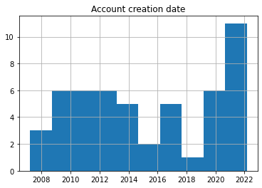

```python
import matplotlib.pyplot as plt

plt.subplot(2,3,1)
creation_date.hist(column='Datetime')
plt.title('Account creation date')
```

# Further analysis ahead

More analysis can be done on here, analysing the time the tweets are shared, and how the tweets are linked each other to identify the entire web of misinformation spreading on social media.How certain misinformation are beign spreaded amoung a particular community. More tasks are to be implemented in the coming days